Integrationen i Dalarna

# Integrationen i Dalarna

Rapporten är skapad av Samhällsanalys, Region Dalarna  
Senast uppdaterad: 2026-11-27

# Sammanfattning

- Dalarnas inrikes födda befolkning har under de senaste decennierna minskat i antal och fått en förändrad åldersstruktur. Färre i arbetsför ålder ska försörja fler, framförallt äldre, som inte arbetar. De senaste decenniernas invandring har därför haft en tydlig positiv effekt genom att både bromsa den negativa befolkningsutvecklingen och bidra till en föryngring av befolkningen och därmed arbetskraftsförsörjning.
- Arbetslösheten bland utrikes födda har historiskt varit högre än bland inrikes födda, men utvecklingen under senare år för utrikes födda visar på en markant positiv utveckling och har nästan halverats sedan år 2020. Med den ökade sysselsättningen ses en positiv utveckling också i form av förbättrad ekonomi, minskad trångboddhet och färre i behov av ekonomiskt stöd bland utrikes födda. Däremot har genomströmningstiden för godkänt i SFI ökat det senaste decenniet, vilket behöver adresseras då språkkunskaperna är viktiga för utbildning och etablering på arbetsmarknaden.
- Faktorer som minskar skillnaderna på arbetsmarknaden mellan utrikes födda och inrikes födda är framförallt höjda utbildningsnivåer och längre vistelsetid i Sverige. Däremot finns det kvarstående skillnader i form av exempelvis lägre medianinkomster, en högre andel trångbodda, en högre andel arbetslösa och även långtidsarbetslösa.
- Sammantaget ses en mycket positiv utveckling i Dalarna, men de kvarstående skillnaderna visar på vikten av ett fortsatt integrationsarbete med fokus på språk, utbildning och arbete för att minska skillnader mellan inrikes och utrikes födda.

# Inledning

I år är det 10 år sedan året då Sverige registrerade det högsta antalet asylsökande genom tiderna. 2015 sökte närmare 163 000 personer asyl i Sverige och för Dalarnas del blev 2016 det år då invandringen var som störst efter att de asylsökande fått uppehållstillstånd och folkbokförts i länet.

År 2019 publicerade Region Dalarna rapporten [Nulägesbeskrivning av integrationen i Dalarna, ett regionalt perspektiv](https://www.regiondalarna.se/contentassets/d845727dbc9f49c3b7b09a2c60456497/integrationsanalys.pdf)[^1]. Rapporten skrevs med syfte att följa upp hur den höga asylinvandringen till Sverige och Dalarna påverkat länet. Efter toppen 2015 låg antalet asylsökande på 20-30 000 per år fram till pandemin, och år 2025 hade det minskat till drygt 6 700, den lägsta nivån sedan 1996. Det är en del i det paradigmskifte som regeringen Kristersson verkat för, med ambitionen att öka arbetskraftsinvandringen och minska asylinvandringen [(Regeringen, 2025)](https://www.regeringen.se/pressmeddelanden/2025/01/pressbriefing-om-migrationen-till-sverige-under-2024/)[^2].

Integration kan ses som *en process där individer eller grupper med olika bakgrunder och förutsättningar blir en del av ett större socialt, ekonomiskt eller kulturellt sammanhang, samtidigt som deras egen identitet och särart respekteras*.

Även om integrationsbegreppet är brett, präglas samhällsdebatten av hur utrikes födda ska integreras i det svenska samhället. Det gör att det är viktigt att belysa utrikes föddas förutsättningar och utveckling i jämförelse med inrikes födda på ett antal samhällsområden så som utbildning, arbetsmarknad och boende, områden som är avgörande för exempelvis kompetens- och arbetskraftsförsörjningen på kort och lång sikt.

Den här rapportens syfte är att redovisa aktuell statistik som kan bidra till förståelsen för utrikes föddas integration i samhället i Dalarna och visa på utvecklingen över tid. Som utgångspunkt finns 2019 års rapport, med anpassningar till dagens situation och kunskapsläge. Rapporten kommer inte att behandla frågor som rör invandringens påverkan på de offentliga finanserna eller utrikes föddas inblandning i brottslighet. För den som är intresserad av att läsa mer om dessa områden rekommenderas rapporter från [Konjunkturinstitutet](https://www.konj.se/media/kpgnt5iw/specialstudie-117-invandrades-nettobidrag-till-de-offentliga-finanserna-1983-2022.pdf) och [Brottsförebyggande rådet](https://bra.se/rapporter/arkiv/2021-08-25-misstankta-for-brott-bland-personer-med-inrikes-respektive-utrikes-bakgrund).

I Region Dalarnas rapport från 2019 konstaterades bland annat att den största skiljelinjen fanns mellan hur väl integrationsprocessen fungerar för gruppen utrikes födda å ena sidan, och inrikes födda å andra sidan oavsett om de inrikes födda har utrikes eller inrikes födda föräldrar. Skillnaden i förutsättningar och förmåga mellan de inrikes födda, oavsett föräldrarnas bakgrund, var relativt liten när det gäller skolresultat och sysselsättningsgrad. Denna rapport belyser därför primärt utrikes födda i jämförelse med inrikes födda. En uppdelning sker även för kvinnor och män, utbildningsnivåer samt vistelsetid i landet i de delar det är relevant. I vissa diagram används även begreppet *Född i Sverige*, vilket ska likställas med inrikes född.

# 1 Befolkningsutveckling och invandring

Sverige är sedan en längre tid inne i en demografisk fas där de stora babyboom-kullarna från slutet av 1940- och början av 1950-talet uppnåt pensionsålder och nästa generation från 1960-talet börjar närma sig pension. Många svenska kommuner har en alltmer ålderstigen befolkning, en effekt av den urbaniseringsvåg som pågått sedan tidigt 1900-tal, då många unga lämnat landsbygden och mindre tätorter till förmån för residens- och universitetsstäder. Förutom att befolkningsutvecklingen medför färre skattebetalare som ska försörja allt fler äldre så innebär den också ett stort arbetskraftsproblem.

En stor andel äldre i befolkningen medför ekonomiska påfrestningar för en kommun då allt färre i arbetsför ålder ska försörja dem som inte förvärvsarbetar, det vill säga äldre och barn. Redan i [Långtidsutredningen (2015)](https://www.regeringen.se/contentassets/86d73b72a97345feb2a8cbc8b6700fa7/sou-2015104-langtidsutredningen-2015-huvudbetankande/)[^3] gjordes beräkningar på hur mycket kommunalskatten skulle behöva höjas i kommunerna för att upprätthålla samma servicenivå år 2040 som då, som en följd av den förändrade demografiska strukturen. Beräkningarna visade på cirka 50-procentiga ökningar, i mångas ögon orimliga skattehöjningar, vilket kan ses som en signal på hur allvarlig situationen var redan för tio år sedan.

I [Långtidsutredningen (2019)](https://www.regeringen.se/contentassets/ec035a7de89549eaacc14d82f54b4396/sou-2019_65_webb.pdf)[^4] beräknas statsbidragen till kommunsektorn, vid oförändrade kommunalskatter, behöva nästan fördubblas fram till 2035 för att möta den demografiskt betingade efterfrågan på kommunala tjänster. Utmaningen ligger dock inte främst i finansieringen, utan i att hitta arbetskraften. Störst brist på personal förväntas uppstå i landsbygdsregioner, vilket riskerar att leda till ökad ojämlikhet i levnadsförhållanden och utvecklingsmöjligheter.

Andelen utrikes födda som är i arbetsför ålder (20-64 år) i Dalarna har ökat successivt över de senaste 20 åren, från ungefär 7 procent år 2000 till ungefär 18 procent år 2025. Ökningen var särskilt tydlig under några år på mitten av 2010-talet i samband med den stora flyktingströmmen och invandringen till Sverige och Dalarna. Utrikes födda har blivit en förutsättning för att kunna arbetskraftsförsörja arbetsmarknaden i Dalarna.

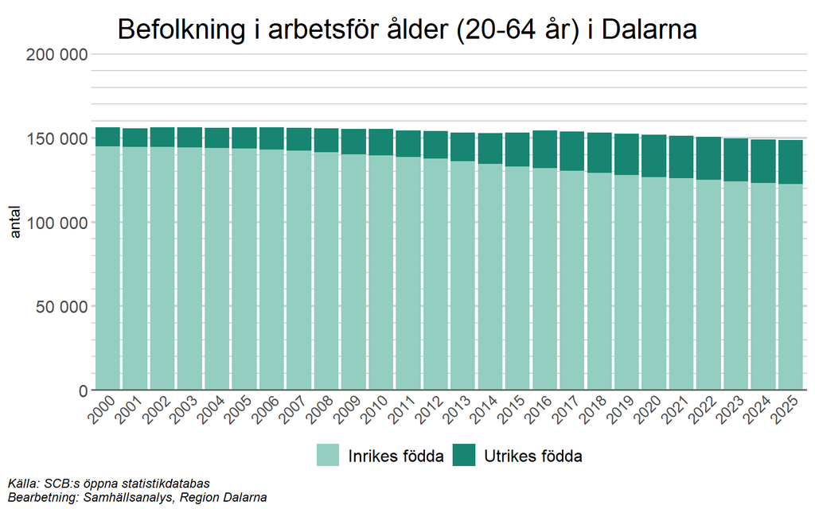

Den totala befolkningen i Dalarna varierar en del över tid och var som störst 1994 med ungefär 291 200 invånare, men minskade därefter till drygt 275 600 år 2007. Vid utgången av 2025 noterades drygt 286 000 invånare i länet, vilket är en minskning från de senaste årens högsta nivå, knappt 288 400 år 2021.

Mellan 2000 och 2025 ökade antalet utrikes födda personer i Dalarnas län från drygt 17 000 till ungefär 37 600 personer, vilket innebär att den utrikes födda befolkningen mer än fördubblats. Ökningen var som starkast fram till 2019, då antalet nådde sin högsta nivå (drygt 37 800). Därefter har nivån legat relativt stabil, med en svag nedgång jämfört med toppåret 2019. Antalet inrikes födda minskade under samma tid från drygt 261 200 personer till drygt 248 400 personer. Genom att studera befolkningsutvecklingen för inrikes och utrikes födda i länet de senaste åren, blir det tydligt att befolkningen i länet som helhet hade minskat utan invandringen.

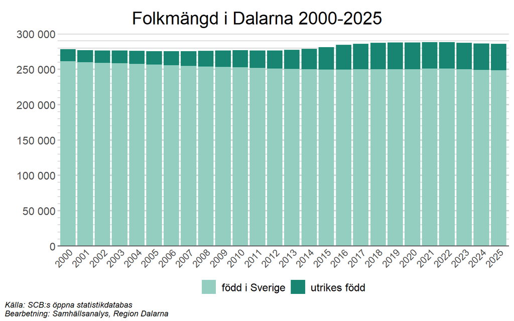

På kommunnivå ökade befolkningen totalt sett i 7 av länets kommuner mellan år 2000–2025, medan den minskade i 8 av dem (se det vänstra diagrammet nedan). Antalet utrikes födda personer har under tidsperioden ökat i Dalarnas läns samtliga kommuner, medan antalet inrikes födda personer har minskat i alla kommuner förutom Falun och Gagnef. Slutsatsen blir att de kommuner i länet som har växt i invånarantal, med undantagen Falun och Gagnef, har gjort det som en följd av invandring, medan de kommuner som krympt har begränsat befolkningsminskningen genom att fler har invandrat än utvandrat. Noteras bör även att utrikes föddas barn ingår i kategorin inrikes födda.

I det högra diagrammet nedan syns att andelen av befolkningen som är utrikes födda är lägre i de allra flesta av Dalarnas kommuner jämfört med riket, där cirka 21 procent av invånarna var födda i ett annat land än Sverige år 2025. Undantaget är Ludvika, som ligger i nivå med riket och har Dalarnas högsta andel utrikes födda (cirka 21 procent). Även Borlänge och Avesta har en relativt stor andel utrikes födda (18 respektive 17 procent). Lägst andel utrikes födda finns i Gagnef, där endast 7 procent av befolkningen är utrikes födda.

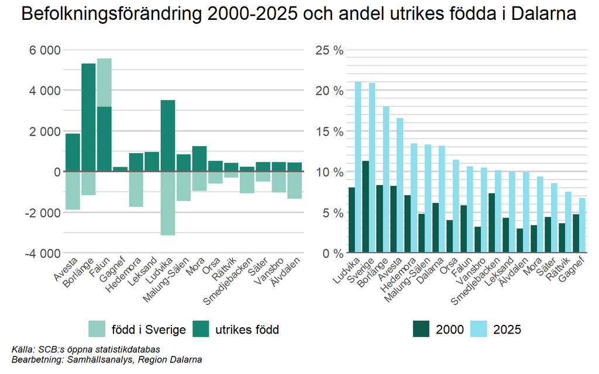

Andelen utrikes födda har ökat i samtliga av Dalarnas kommuner mellan 2000 och 2025, vilket kommer av att invandringen varit större än utvandringen under hela 2000-talet, samtidigt som antalet inrikes födda minskat i de flesta kommuner. Hur stor ökningen varit skiljer dock tydligt mellan kommunerna. I Ludvika har andelen utrikes födda exempelvis ökat med 13 procentenheter sedan 2000, medan ökningen har varit klart lägre i näraliggande Smedjebacken (ungefär 3 procentenheter under samma tidsperiod) eller Gagnef (ungefär 2 procentenheter).

För att förstå befolkningsutvecklingen i Dalarna är det även viktigt att undersöka de beteendemönster som, vid sidan om invandringen, påverkar befolkningsutvecklingen; födelseöverskottet och den inrikes flyttningen.

Mellan år 2000 och 2025 har antalet döda i Dalarna varit fler än antalet födda och antalet utflyttade till övriga Sverige har varit fler än antalet inflyttade från övriga Sverige. Totalt flyttade ungefär 14 800 personer netto från Dalarna till andra delar av Sverige under perioden, medan det dog ungefär 13 200 fler personer än det föddes. Under samma period var invandringsöverskottet ungefär 32 800 personer. Att Dalarnas befolkning har växt under 2000-talet beror således på att invandringen har varit relativt stor.

Vid en analys av åldersfördelningen bland Dalarnas befolkning uppdelat på den inrikes- och utrikes födda befolkningen blir det tydligt att den utrikes födda befolkningen i länet är väsentligt yngre än den inrikes födda, och innefattar en större andel personer i arbetsför ålder (se de svarta linjerna i diagrammet nedan). Detta beror på att personer som invandrar generellt är yngre än genomsnittet för en befolkning. Följden blir att invandringen totalt sett har gett en föryngrande effekt på befolkningen. Det finns även stora variationer i medelålder mellan olika grupper av utrikes födda beroende på invandringsår och födelseland. Utrikes födda utgör ungefär 13 procent av den totala befolkningen i Dalarnas län och är därmed betydligt färre än inrikes födda.

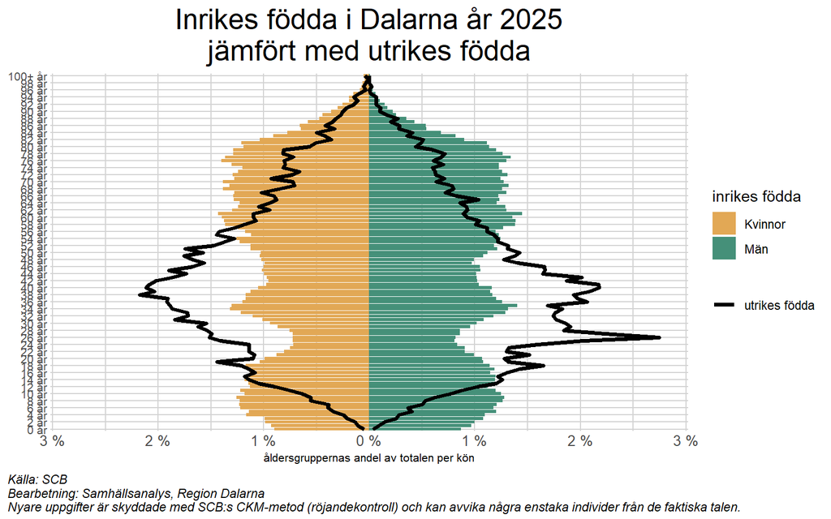

Befolkningen i arbetsför ålder (20-64 år) är särskilt intressant att fokusera på då den bidrar till att balansera en allt äldre befolkning och förbättrar möjligheten att säkerställa tillgång till arbetskraft för näringsliv och offentlig sektor i framtiden.

Enligt SCB:s befolkningsprognos från juni 2024 förväntas antalet utrikes födda i Dalarnas län mellan 20-64 år att öka med 702 personer mellan 2025 och 2040, medan antalet inrikes födda personer i länet förväntas att minska med 6 029 personer [(SCB Statistikdatabasen)](https://www.statistikdatabasen.scb.se/pxweb/sv/ssd/START__BE__BE0401__BE0401A/BefProgRegFakN/)[^5].

Enligt prognosen kommer antalet personer mellan 20-64 år således att minska tydligt i Dalarna fram till 2040, vilket förstärker länets utmaningar med arbetskrafts- och kompetensförsörjning. Det blir då extra viktigt att ta vara på den resurs som utrikesfödda kan utgöra, annars riskerar såväl näringsliv som offentlig sektor att få mycket svårt med arbetskraftsförsörjningen.

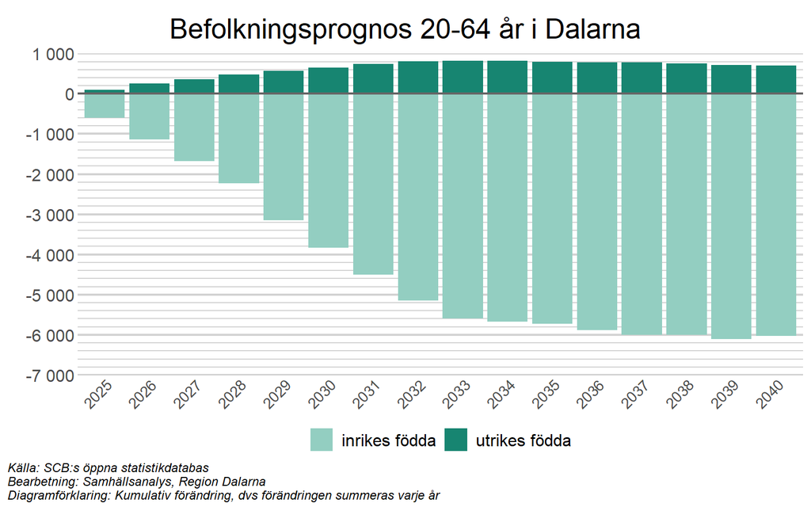

Den demografiska översikten visar således att andelen utrikes födda i Dalarna ökat över tid och bidragit till att både föryngra och vidmakthålla länets invånarantal.

# 2 Språk och utbildning

Ett viktigt steg för att kunna integreras i ett samhälle är att lära sig språket. Språkkunskaper ger förutsättningar för utbildning som i sin tur skapar möjligheter på arbetsmarknaden. I detta avsnitt görs en genomgång av utvecklingen för utrikes födda inom språk och utbildning. I nästa avsnitt diskuteras utvecklingen på arbetsmarknaden.

## 2.1 Språk

Att ha grundläggande kunskaper i det officiella språket är viktigt för att kunna delta i samhället, både socialt, ekonomiskt och kulturellt. För att underlätta integrationen av nyanlända har Sverige ett system för svenskundervisning för invandrare, hädanefter benämnt SFI. SFI är en utbildning som erbjuds till personer som är bosatta i Sverige men saknar sådana grundläggande kunskaper i svenska språket som utbildningen syftar till att ge. Från andra kalenderhalvåret det år hen fyller 16 år har personen rätt till SFI ([Skolverket](https://www.skolverket.se/regler-och-ansvar/ansvar-i-skolfragor/ratt-till-sfi)).

För de personer boende i Dalarna som blivit godkända i SFI har vistelsetiden i Sverige fram till godkända studier förändrats relativt mycket över tid och på senare tid ökat, oavsett indidivens utbildningsnivå. Under några år i slutet på 1990-talet hade de män och kvinnor med förgymnasial utbildning som blivit godkända i SFI varit i Sverige ungefär 1300-1400 dagar (medianvärde). Därefter såväl ökade som minskade vistelsetiden fram till mitten av 2010-talet, innan den ökade tydligt fram till åren runt pandemin (2020-2021). År 2023 hade de män och kvinnor med förgymnasial utbildning som blev godkända i SFI i Dalarna varit i Sverige i 1693 dagar, vilket är ungefär lika länge som de som blev godkända åren innan. För personer med längre utbildningar (gymnasial eller eftergymnasial) är trenden liknande, men vistelsetiden generellt kortare.

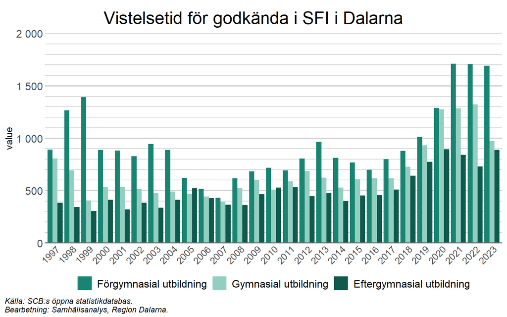

Hur lång tid det tar att slutföra SFI, från när personen invandrade till Sverige (vistelsetid), påverkas av vilken utbildningsnivå den invandrade har. Kvinnor med förgymnasial utbildning som blev godkända i SFI år 2023 hade varit i Sverige i 1954 dagar (medianvärde), att jämföra med 817 dagar för kvinnor med gymnasial utbildning. För kvinnor med högst utbildning (eftergymnasial) tog det 906 dagar, vilket alltså är något längre tid än för de med gymnasial utbildning.

Män med förgymnasial utbildning som blev godkända i SFI under år 2023 hade varit i Sverige betydligt kortare tid än kvinnorna med motsvarande utbildning, 1056 dagar (medianvärde). Till skillnad från kvinnorna hade dock de män med gymnasial utbildning som blivit godkända under år 2023 varit i Sverige längre tid än motsvarande personer med förgymnasial utbildning, hela 1437 dagar, vilket även är klart längre än kvinnorna med gymnasial utbildning som blev godkända. De män med längst utbildning (eftergymnasial) hade varit i Sverige i 823 dagar när de blev godkända i SFI år 2023, vilket är något kortare tid än kvinnorna med motsvarande utbildning.

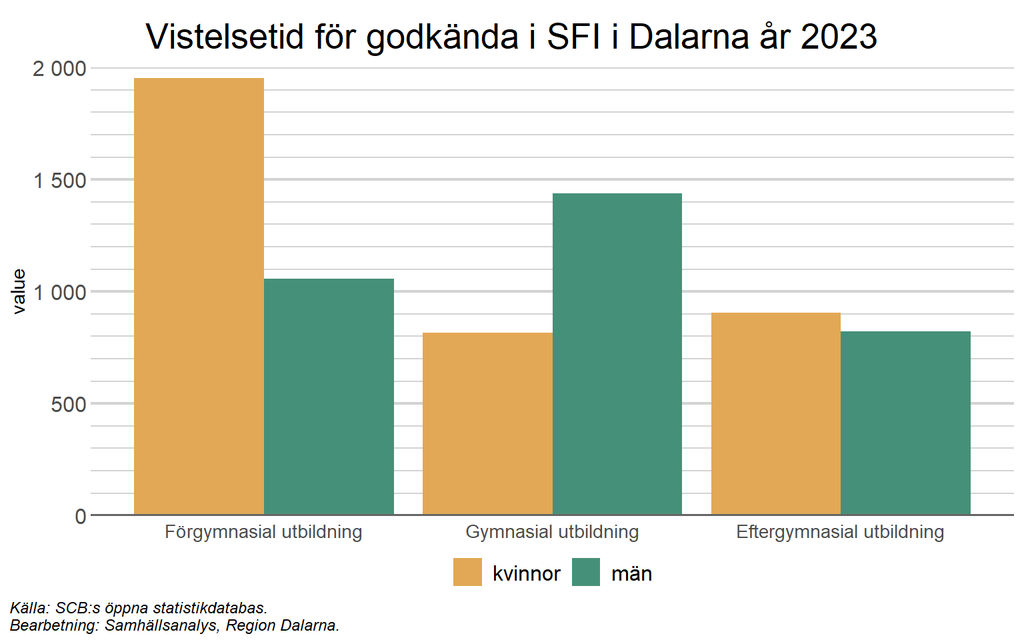

En orsak till att vistelsetiden ökade stadigt för de som blev godkända från mitten av 2010-talet, oavsett utbildningsbakgrund, kan vara att många då invandrade till Sverige. Det, i kombination med en pandemi som sannolikt försvårade möjligheterna till undervisning, kan ha gjort att det tog längre tid att slutföra SFI och har resulterat i historiskt långa vistelsetider för att nå godkänt i SFI.

Från 1 januari 2025 har kraven på att delta i SFI skärpts. Deltagande är bland annat begränsat till tre år och en individuell studieplan ska upprättas i samband med antagning. Det innebär att genomströmningstiderna behöver återgå till den nivå som rådde innan pandemin, utan att kvaliteten i utbildningen försämras. En sänkning av genomströmningstiderna ökar i sin tur möjigheten att gå vidare i utbildningssystemet och skynda på integrationsprocessen.

## 2.2 Utbildning

En fullgjord gymnasieutbildning är en av de viktigaste faktorerna för ett gott liv på många sätt, såsom hälsa, inkomst, medellivslängd och möjligheten till arbete. De med en högre utbildning lever generellt längre ([SCB](https://www.scb.se/hitta-statistik/statistik-efter-amne/befolkning-och-levnadsforhallanden/befolkningens-sammansattning-och-utveckling/demografisk-analys/pong/statistiknyhet/livslangd-efter-utbildningsniva/)), har en genomsnittligt högre inkomst ([SCB](https://www.scb.se/hitta-statistik/sverige-i-siffror/utbildning-jobb-och-pengar/medelloner-i-sverige/)) och mår i allmänhet bättre än de med lägre utbildning ([FHM](https://www.folkhalsomyndigheten.se/contentassets/ca6067606d8847f7945e922642853caf/utbildning-halsa-faktablad.pdf)). Utbildningsnivån hos utrikes födda har därför en stor påverkan på möjligheterna att etablera sig i samhället, särskilt bland de unga som anländer till Sverige under skolåren och har hela arbetslivet framför sig. Idag behövs det enligt Arbetsförmedlingen i regel gymnasiekompetens för att ha en god chans att etablera sig på arbetsmarknaden, även när det gäller bristyrken.

Att gruppen utrikes födda är en heterogen grupp blir tydligt när utbildningsnivån studeras (se diagram nedan). Den största skillnaden mellan utrikes och inrikes födda är att en större andel av de utrikes födda har en förgymnasial utbildning och en mindre andel gymnasial utbildning. Andelen personer som har eftergymnasial utbildning är ungefär densamma för inrikes och utrikes födda. En lite högre andel kvinnor födda i Sverige har eftergymnasial utbildning än utrikes födda kvinnor, men bland män är förhållandet det omvända. Arbetskraftsinvandrare har generellt sett en högre utbildningsnivå än flyktinginvandrare, och skillnaderna i utbildningsnivå är även stora mellan olika ursprungsländer.

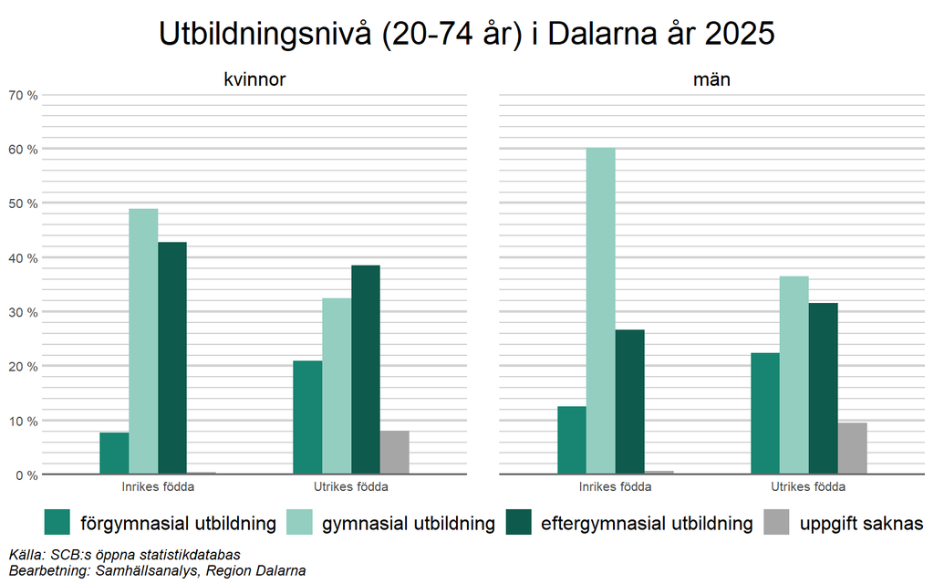

Eftersom det finns stora skillnader i utbildningsbakgrund bland utrikes födda, är det svårt att tala om dem som en samlad grupp. Personer med låg respektive hög utbildning stöter på olika typer av utmaningar på arbetsmarknaden.

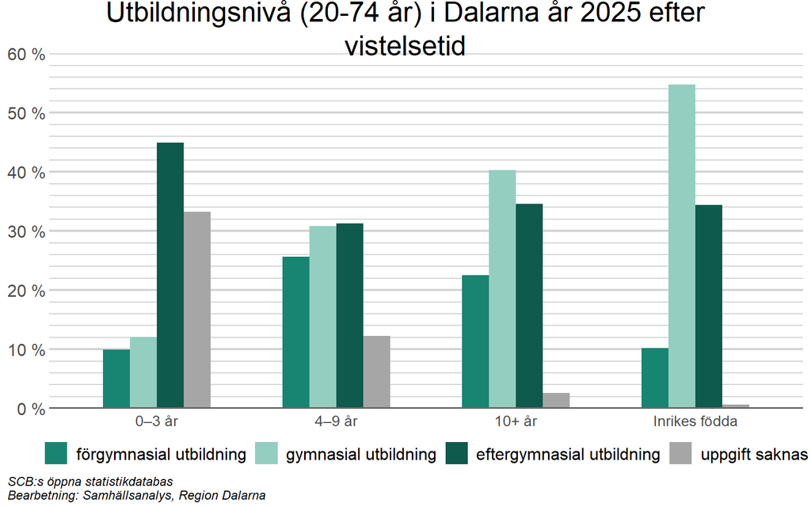

Viktigt att notera är även att det saknas uppgifter om utbildningsnivå för en stor andel av de utrikes födda, speciellt för dem som varit en kortare tid i landet.

Eftersom en gymnasieutbildning förbättrar möjligheten att etablera sig på arbetsmarknaden är en viktig aspekt att undersöka hur stor andel av avgångseleverna i årskurs 9 i länet som är behöriga till att påbörja gymnasiestudier. Ofullständiga eller låga betyg är i första hand ett problem för den enskilde, då personens valmöjligheter begränsas och etableringen på arbetsmarknaden försvåras. Att en stor andel elever inte blir behöriga till gymnasiet kan även innebära ett samhällsproblem. Samhället misslyckas med att ta tillvara på elevernas potential om de inte når målen för utbildningen i skolan. Det finns även ett starkt samband mellan dåliga skolresultat och sociala problem [(Westin Lundqvist, W. m fl, 2019)](https://www.hv.se/contentassets/82eff73069584573b03f43956b661c05/laga-skolresultat-i-socialt-utsatta-omraden_.pdf)[^6].

Skillnaden i andelen behöriga till gymnasiet hos avgångselever i årskurs 9 mellan inrikes och utrikes födda är fortsatt stor i Dalarna. Sedan 2005 har gymnasiebehörigheten för inrikes födda minskat från 91 procent till 86 procent år 2023. Skillnaden mellan inrikes födda pojkar och flickor är marginell men utvecklingen har varit svagt negativ sedan 2005.

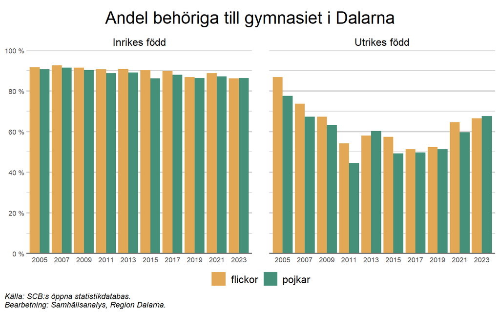

För utrikes födda, både pojkar och flickor, har det varit en stor variation under de senaste 20 åren. 2005 var behörigheten för utrikes födda flickor cirka 5 procentenheter lägre än för inrikes födda flickor. För utrikes födda pojkar var skillnaden nästan tre gånger så stor vid samma tidpunkt. Sedan dess har andelen behöriga utrikes födda flickor fallit fram till 2017, för att därefter öka till 66 procent år 2023. För utrikes födda pojkar var minskningen som störst fram till 2011 för att därefter öka från 44 procent till 68 procent år 2023. Det innebär att utrikes födda pojkar har en högre andel behöriga till gymnasiet än utrikes födda flickor år 2023, vilket är första gången sedan 2013.

Det finns stora skillnader i gymnasiebehörighet mellan grupper med olika vistelsetid i Dalarna där behörigheten är större ju längre eleverna har vistats i Sverige (se diagram nedan). Behörigheten för elever som går ut årskurs 9 med en vistelsetid som är 10 år eller längre, är i det närmaste att likställa med behörigheten för inrikes födda. I gruppen med en vistelsetid 4-9 år är behörigheten omkring 20 procentenheter lägre och i gruppen vistelsetid 2-3 år är den ytterligare 24 procentenheter lägre, vilket innebär att ungefär 40 procent i gruppen har gymnasiebehörighet.

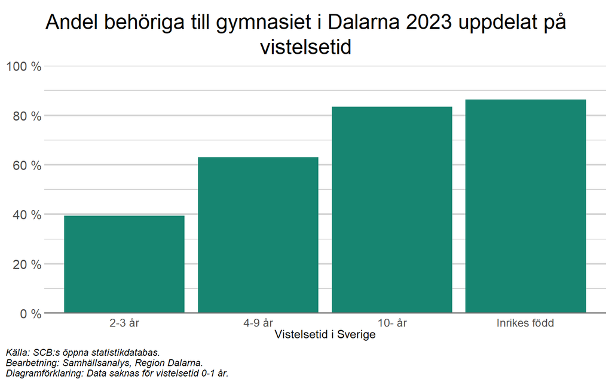

[Mörtlund (2020)](https://www.ifau.se/Forskning/Publikationer/Rapporter/2020/arbetet-med-nyanlanda-elever-i-grundskolan/)[^7] noterade stora utmaningar med att kvalitetssäkra undervisningen i grundskolan, trots insatser kring språk- och kunskapsutvecklande arbetssätt. Att på en kort tid lära sig svenska språket och samtidigt utveckla ämneskunskaper är en svår utmaning.

# 3 Arbetsmarknad

I förlängningen av att studera är att arbeta en viktig komponent i integrationen i samhället. Utrikes födda har generellt en svagare ställning på arbetsmarknaden, vilket speglas i att sysselsättningen bland utrikes födda är lägre än bland inrikes födda personer, samt att arbetslösheten, inklusive långtidsarbetslösheten, är högre. Forskning visar att bland annat härkomst, ålder, kön, utbildningsnivå, konjunkturläge, språkkunskaper och kontaktnät är avgörande för utrikes föddas möjligheter att etablera sig på arbetsmarknaden [(IFAU, 2022)](https://www.ifau.se/Press/Forskningssammanfattningar/Utrikes-foddas-eta-pa-arbetsmarknaden-/)[^8]. Arbetslöshets- och sysselsättningsnivåerna bland utrikes födda varierar dock stort mellan olika grupper.

## 3.1 Arbetslöshet och sysselsättning

Arbetsmarknadsstatistik finns både hos SCB och Arbetsförmedlingen, men i denna rapport används statistik från SCB. För mer information om arbetsmarknadsstatistiken, klicka nedan:

**Mer information om arbetsmarknadsstatistiken**

Arbetslösheten visar hur många av de aktivt arbetssökande som inte har ett arbete. I denna rapport används främst SCB:s statistik, antingen via Arbetskraftsundersökningarna (AKU) eller Befolkningens arbetsmarknadsstatus (BAS). I fallet med långtidsarbetslöshet hämtas data från Kolada.se, med Arbetsförmedlingen som grundkälla.

SCB:s Arbetskraftsundersökningar (AKU) beskriver utvecklingen på arbetsmarknaden för Sveriges befolkning i åldern 15–74 år. AKU visar bland annat antal och andel sysselsatta respektive arbetslösa per månad, kvartal och år. Det är den enda källan med kontinuerliga uppgifter om den totala arbetslösheten och står för det officiella arbetslöshetstalet.

Enligt AKU är en person *sysselsatt* om den under mätveckan har arbetat minst en timme, eller varit tillfälligt frånvarande från ett arbete (semester, tjänstledighet, sjukdom, osv). Även personer som deltar i vissa arbetsmarknadspolitiska program räknas som sysselsatta (lönebidrag, start av näringsverksamhet osv).

Arbetslösa är personer som var utan arbete under mätveckan, men som sökt arbete under de senaste fyra veckorna (mätveckan och tre veckor bakåt) och kunde arbeta mätveckan eller börja inom 14 dagar från mätveckans slut. Arbetslösa omfattar även personer som har fått ett arbete som börjar inom tre månader, förutsatt att de skulle ha kunnat arbeta mätveckan eller börja inom 14 dagar från mätveckans slut.

AKU är en urvalsundersökning som genomförs genom intervjuer och är inte nedbrytbar på finare geografisk nivå än län och storstadsregioner. För att analysera sysselsättning på finare geografisk nivå än vad som finns i AKU kan registerstatistik i form av Befolkningens arbetsmarknadsstatus (BAS) (tidigare Registerbaserad arbetsmarknadsstatistik (RAMS)).

Syftet med BAS är att redovisa den folkbokförda befolkningen i sex arbetsmarknadsstatusar; Sysselsatta, Arbetslösa, Studerande, Pensionärer, Sjuka samt Övriga. De sysselsatta redovisas i statistiken för åldersgruppen 15–74 år och kan delas upp i anställda och egenföretagare. Sysselsatta definieras genom att man antingen fått lön som utgör underlag för arbetsgivaravgift, som redovisats i AGI eller i förenklad arbetsgivardeklaration. Alternativt att man som företagare redovisat underlag för förväntad moms. Även tillfälligt frånvarande som föräldralediga och sjukskrivna räknas med som sysselsatta, liksom folkbokförda i Sverige som arbetar i annat nordiskt land.

Vid längre jämförelser över tid används både BAS och RAMS.

Arbetsförmedlingen rapporterar också arbetslöshetsstatistik, men den skiljer sig från SCB:s p g a ett annat dataunderlag och mått. För en jämförelse mellan SCB:s och Arbetsförmedlingens statistik, se [Arbetsförmedlingen](https://arbetsformedlingen.se/statistik/sok-statistik/forklaring-av-statistiken/arbetsformedlingens-och-scbs-statistik)).

Som långtidsarbetslös räknas den som har varit öppet arbetslös eller i program med aktivitetsstöd i minst sex månader.

För inrikes födda har arbetslösheten minskat något sedan coronapandemin (2020-2021), men varit relativt stabil på senare år. I augusti 2026 var arbetslösheten bland inrikes födda 2,4 procent i Dalarna. Bland utrikes födda har arbetslösheten minskat stadigt och markant sedan en topp under pandemin (den var 22,5 procent i juni 2020), men är klart högre än bland inrikes födda (10,6 procent i augusti 2026).

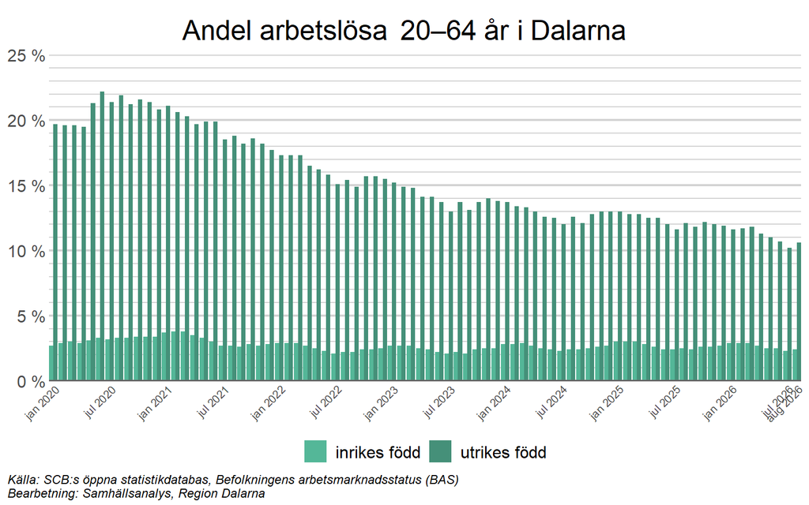

Att en större andel utrikes födda arbetar idag, jämfört med för ett par år sedan, är mycket viktigt för integrationen, då möjligheten att försörja sig själv och skapa nya sociala sammanhang ses som en av de viktigaste faktorerna för att integreras i samhället ([Jönköpings universitet](https://ju.se/forskning/langlasning/arkiv/2022-03-04-engagemang-kontakter-och-sprakkunskaper-ger-snabbare-integration-pa-arbetsmarknaden.html)).

I Dalarna är skillnaden i arbetslöshet mellan utrikes och inrikes födda knappt 11 procentenheter för kvinnor och 6 procentenheter för män.

Bland länets kommuner är variationen i arbetslöshet stor. För inrikes födda var arbetslösheten något högre för män än för kvinnor, men generellt låg i samtliga Dalarnas kommuner. Högst arbetslöshet för inrikes födda män i Dalarna finns i Hedemora, men skillnaden gentemot genomsnittet i länet är relativt liten.

Bland inrikes födda kvinnor finns den högsta arbetslösheten i Hedemora.

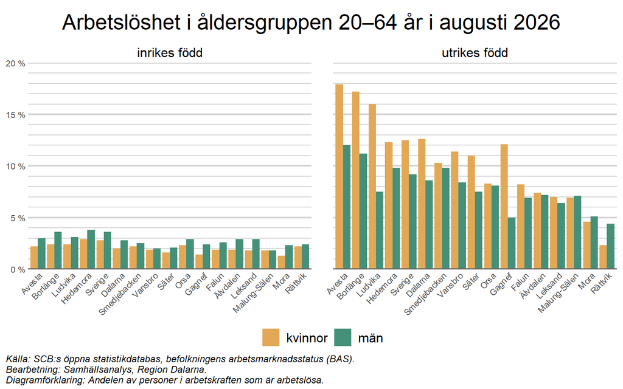

Bland utrikes födda är arbetslösheten avsevärt mycket högre för både kvinnor och män, och i de flesta kommuner är arbetslösheten högre för utrikes födda kvinnor än för utrikes födda män. Genomsnittet i Dalarnas län ligger på 12,6 procent bland utrikes födda kvinnor och 8,6 procent bland utrikes födda män. I de allra flesta kommuner är arbetslösheten dessutom klart högre för utrikes födda jämfört med inrikes födda, oavsett kön.

Arbetslösheten för utrikes födda kvinnor i Dalarna är högst i Avesta, där arbetslösheten i gruppen är hela 17,9 procent. För inrikes födda kvinnor är motsvarande siffra blott 2,2 procent. För utrikes födda män i Dalarna är arbetslösheten högst i Avesta, med en arbetslöshet i gruppen på 12 procent. För inrikes födda män är motsvarande siffra 3 procent.

Lägst arbetslöshet bland utrikes födda kvinnor har Rättvik med 2,3 procent. För inrikes födda kvinnor är motsvarande siffra bara något lägre, 2,2 procent. Bland utrikes födda män är arbetslösheten lägst i Rättvik med 4,4 procent. För inrikes födda män är motsvarande siffra 2,4 procent.

Totalt var 2 680 inrikes födda personer och 2 245 utrikes födda personer i åldersgruppen 20–64 år arbetslösa i Dalarna i augusti 2026.

Hur långt ifrån arbetsmarknaden som en individ befinner sig beror delvis på hur länge personen har varit utan anställning. En person som har varit arbetslös länge har ofta svårare att ta sig tillbaka in på arbetsmarknaden. Bland arbetslösa inrikes födda i åldersgruppen 20-64 år har ungefär 29 procent varit arbetslösa länge (minst 24 månader) och får anses stå väldigt långt från arbetsmarknaden. Sammanlagt har ungefär 44 procent av de inrikes födda i åldersgruppen som är arbetslösa varit det i minst 12 månader. Istället är det de som har varit arbetslösa under en relativt kort period (<6 månader) som är den största gruppen (ca 39 procent av alla inrikes födda arbetslösa).

Bland utrikes födda är bilden delvis annorlunda. Här är den största gruppen arbetslösa de som varit det i minst 24 månader, totalt 42 procent av de arbetslösa utrikes födda tillhör den gruppen. Sammanlagt har ungefär 63 procent av de arbetslösa utrikes födda varit det i minst 12 månader.

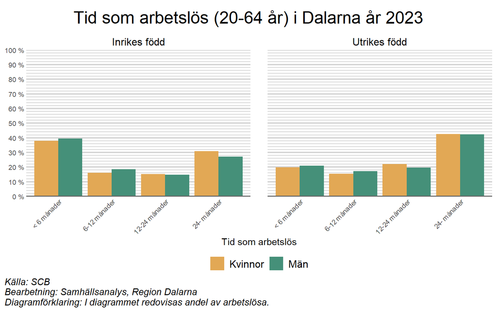

Fördelningen är relativt jämn mellan kvinnor och män. Bland inrikes födda har en något större andel kvinnor än män varit arbetslösa länge (mer än 24 månader), medan en något större andel män än kvinnor varit arbetslösa under en kort period. För utrikes födda har ungefär lika stor andel kvinnor som män varit arbetslösa i minst 24 månader.

Sysselsättningsgraden, det vill säga i vilken utsträckning människor i arbetsför ålder (20-64 år) arbetar, är ett annat sätt att titta på arbetsmarknaden. Den mäter andelen av hela befolkningen som har ett arbete.

I Dalarna var sysselsättningsgraden bland utrikes födda män 76 procent, vilket är cirka 8 procentenheter fler än för utrikes födda kvinnor i Dalarna.

Sysselsättningsgraden i åldersgruppen 20-64 år har ökat för såväl inrikes som utrikes födda i Dalarna sedan det tidiga 1990-talet. År 1993 var sysselsättningsgraden för inrikes födda kvinnor i Dalarna 72,6 procent, vilket var något högre än för männen, 71,4 procent. Att de inrikes födda kvinnornas sysselsättningsgrad var högre än männens beror sannolikt på 90-talskrisen, när branscher med stor dominans av män bland de anställda (industri exempelvis) drabbades hårt.

För utrikes födda var sysselsättningsgraden ungefär lika stor för kvinnor och män, men klart lägre än för inrikes födda (50 procent för kvinnor och 50,6 procent för män). Den här utvecklingen innebär att skillnaden i sysselsättningsgrad mellan utrikes och inrikes födda män har minskat de senaste 30 åren. Sedan mitten på 2010-talet har utvecklingen varit särskilt stark för utrikes födda män. Däremot kvarstår nästan hela den relativa skillnaden mellan utrikes och inrikes födda kvinnor över tid.

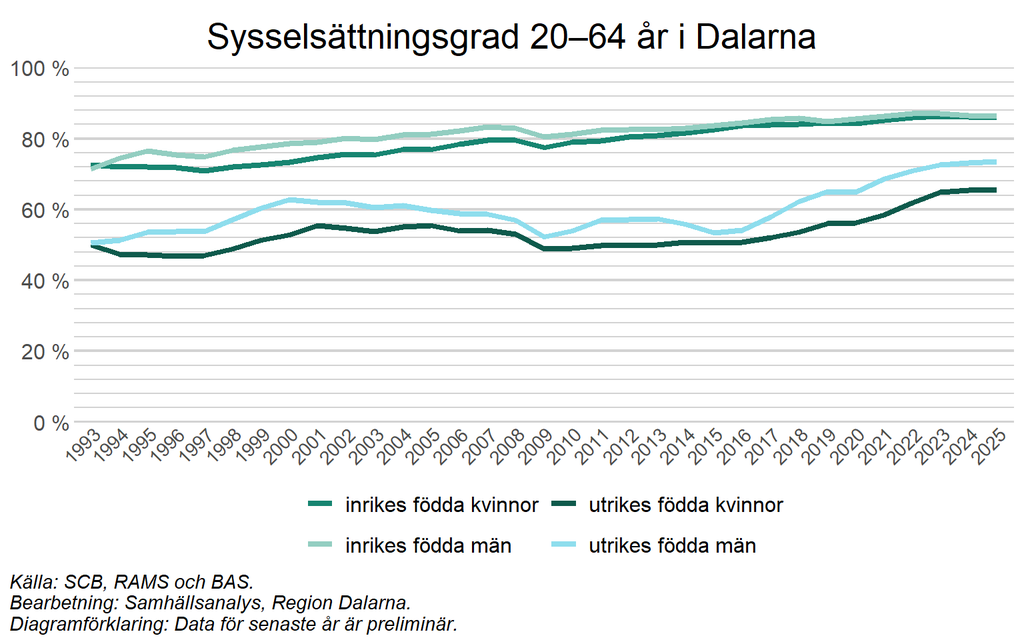

Gruppen inrikes födda har en högre sysselsättningsgrad i samtliga kommuner i Dalarna jämfört med utrikes födda. Även här är sysselsättningsgraden för inrikes födda kvinnor och män ungefär lika hög. För utrikes födda är det däremot stora skillnader mellan kvinnor och män, också mellan olika kommuner. Sysselsättningsgraden är högre för gruppen utrikes födda män i jämförelse med utrikes födda kvinnor i de flesta kommuner. Sysselsättningsgraden för utrikes födda män skiljer sig dock åt mellan kommuner där den högsta sysselsättningsgraden finns i Gagnef (83 procent) och den lägsta i Älvdalen (67,1 procent).

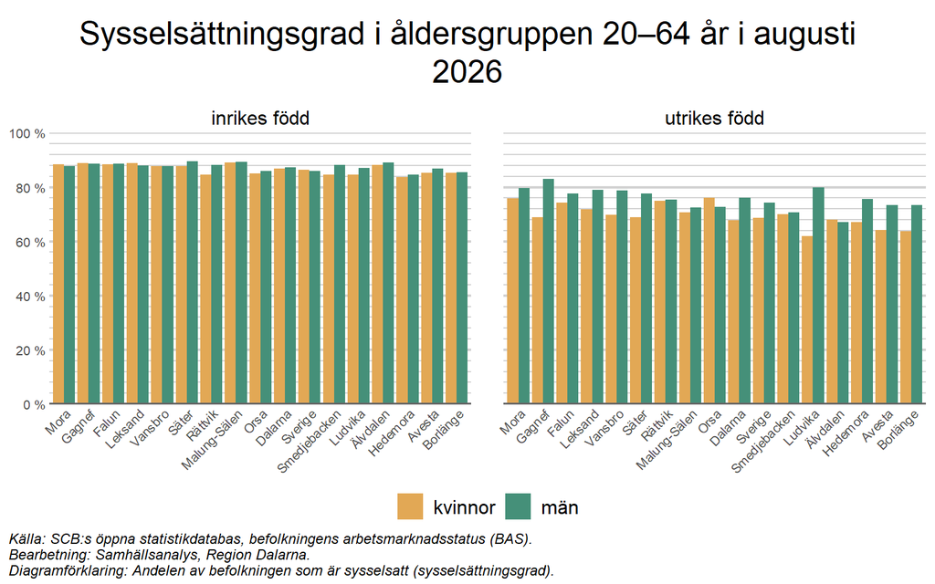

Orsa har den högsta sysselsättningsgraden för gruppen utrikes födda kvinnor i Dalarna, 76 procent, och ligger klart över genomsnittet för länet. Samtidigt är sysselsättningsgraden i Ludvika kommun bland utrikes födda kvinnor bara 61,9 procent.

En del av skillnaden i utrikes föddas sysselsättningsgrad mellan kommunerna kan sannolikt förklaras av skillnader i antalet personer som invandrade under åren runt 2015 då invandringen till Sverige var mycket stor, vilket påverkar individers tid att etablera sig på arbetsmarknaden. Exempelvis var Avesta, Ludvika och Hedemora de tre kommuner som hade högst invandring i förhållande till folkmängd under 2015-2017. Detta förefaller i första hand gälla för utrikes födda kvinnor, då både Hedemora och Ludvika har relativt hög sysselsättningsgrad för utrikes födda män, medan den är klart lägre för utrikes födda kvinnor. I Ludvika är skillnaden mellan könen i sysselsättningsgrad ungefär 18 procentenheter, vilket är den största skillnaden i länet.

När andelen sysselsatta redovisas per utbildningsnivå är det tydligt att individer med förgymnasial utbildning i lägre utsträckning är förvärvsarbetande (se diagram nedan), vilket även gäller gruppen utrikes födda. För personer med förgymnasial utbildning är sysselsättningsgraden bland utrikes födda i Dalarna blott 53,5 procent medan den är 64,9 procent för inrikes födda med motsvarande utbildning, en skillnad på 11,4 procentenheter mellan inrikes och utrikes födda. I avsnittet om utbildning noteras att bland utrikes födda är det män och kvinnor med förgymnasial utbildning som bidrar till den låga sysselsättningsgraden.

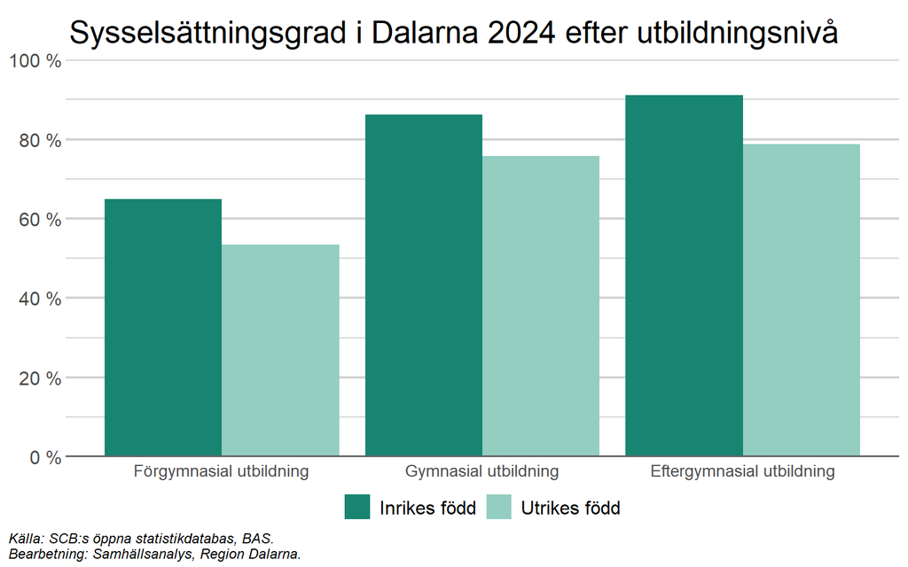

För såväl utrikes som inrikes födda ökar sysselsättningsgraden tydligt om personerna istället har en gymnasial utbildning. Då ökar sysselsättningsgraden bland utrikes födda till 75,8 procent medan den för inrikes födda är 86,2 procent. Det ger en skillnad på 10,4 procentenheter mellan inrikes och utrikes födda.

Bland personer med eftergymnasial utbildning är sysselsättningsgraden för utrikes födda 78,7 procent, vilket bara är något högre än för gymnasialt utbildade i samma grupp. För inrikes födda med en eftergymnasial utbildning är sysselsättningsgraden hela 91,1 procent, vilket är 12,4 högre än för utrikes födda med samma utbildningsnivå.

Hur snabbt en nyligen invandrad person etableras på arbetsmarknaden är nära kopplat till vilken utbildningsnivå personen har. För dem med högst utbildning har det visat sig att processen tenderar att gå relativt snabbt och cirka 44 procent av kvinnorna och 73 procent av männen arbetar innan de varit i Sverige i 2 år (0-1 år i figuren nedan). Sedan ökar etableringsgraden över tid och efter 10 år och längre är 84 procent av kvinnorna mellan 20 och 65 år sysselsatta. För dem med gymnasial utbildning är situationen delvis annorlunda. I den gruppen arbetar ungefär 29 procent av de utrikesfödda kvinnor, och cirka 57 procent av de utrikesfödda männen, inom 2 år efter att de kommit till Sverige. Över tid ökar andelen etablerade snabbt på arbetsmarknaden, särskilt för gymnasialt utbildade.

För dem med lägst utbildningsnivå (förgymnasialt utbildade) är relativt få etablerade på arbetsmarknaden. I den gruppen arbetar bara ungefär 18 procent av de utrikesfödda kvinnor, och cirka 39 procent av de utrikesfödda männen, inom 2 år efter att de kommit till Sverige. Andelen etablerade ökar sedan med vistelsetiden, men är på klart lägre nivåer än för grupper med högre utbildningsnivåer. Även bland inrikes födda är det en klart lägre andel med förgymnasial utbildning som är etablerade på arbetsmarknaden.

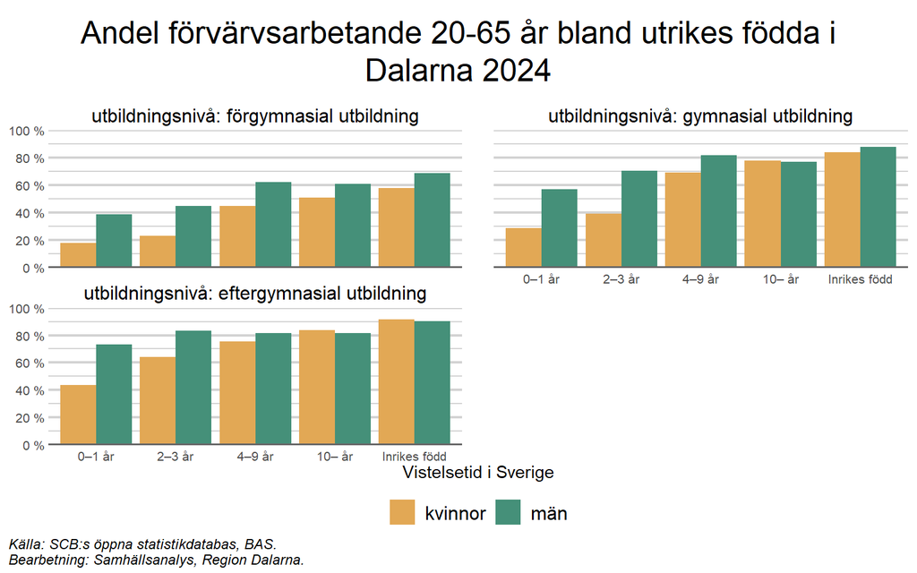

En bidragande orsak till att utrikes födda personer med låg utbildning har svårare att etablera sig på arbetsmarknaden kan vara att det finns få enkla jobb på den svenska arbetsmarknaden som inte kräver längre utbildning. För att möjliggöra att fler av de utrikes födda som flyttar till Dalarna ska arbeta, är det av största vikt att så många som möjligt tillgodogör sig en utbildning som efterfrågas av arbetsmarknaden.

Det finns flera tänkbara anledningar till att utrikes födda i genomsnitt presterar sämre på arbetsmarknaden, även när hänsyn tas till skillnader i utbildningsnivå. Några tänkbara förklaringar kan exempelvis vara lägre kunskaper om landet, språket och kulturen. För de som flyttat till Sverige av flyktingskäl kan traumatiska upplevelser också inverka. Det finns emellertid rapporter som visar att diskriminering av personer med utländskt ursprung förekommer på arbetsmarknaden [(Länsstyrelsen Stockholm, 2018)](https://www.diva-portal.org/smash/get/diva2:1273400/FULLTEXT01.pdf)[^9]. Utrikes födda män förefaller vara mer utsatta inom yrken där det finns många inrikes födda [(Bursell, M. och Bygren, M., 2023)](https://www.ifau.se/globalassets/pdf/se/2023/2023-10-etnisk-yrkessegregering-pa-arbetsmarknaden--har-diskriminering-nagon-betydelse.pdf)[^10].

Om fokus enbart är på kopplingen mellan vistelsetid och sysselsättningsgrad, blir det tydligt att vistelsetiden är en viktig faktor för att skapa integration i samhället (se diagrammet nedan). De som vistats längre tid i Sverige har en högre förvärvsfrekvens. Variabeln vistelsetid fungerar som en indikator på en rad andra faktorer som påverkar möjligheterna till att få ett arbete. Ökad tid i landet ger möjlighet för en nyanländ person att lära sig svenska, validera och komplettera utbildningar, lära sig hur den svenska arbetsmarknaden fungerar samt knyta kontakter för att öka chansen till att få en sysselsättning och inkomst. Enligt detta resonemang förväntas ett initialt sysselsättningsgap mellan inrikes födda och nyanlända, som minskar succesivt när vistelsetiden i landet blir längre.

Som diskuterats tidigare är sysselsättningsgraden lägre bland utrikes födda generellt, och för invandrade kvinnor tar det betydligt längre tid än för invandrade män att etablera sig på arbetsmarknaden. Skillnaderna som finns mellan arbetslöshet och sysselsättningsgrad kan indikera att en större andel utrikes födda kvinnor än män i arbetsför ålder inte står till arbetsmarknadens förfogande. För utrikesfödda kvinnor som befunnit sig i Sverige i upp till 2 år (0-1 år i diagrammet nedan) är det bara ungefär 34 procent i arbetsför ålder (20-65 år) som arbetar. För motsvarande grupp av män är ungefär 63 procent i arbete inom 2 år. Över tid tenderar ändå sysselsättningsgraden att öka avsevärt och efter mer än tio år i Sverige är det över 70 procent av invandrade, såväl män som kvinnor, som arbetar.

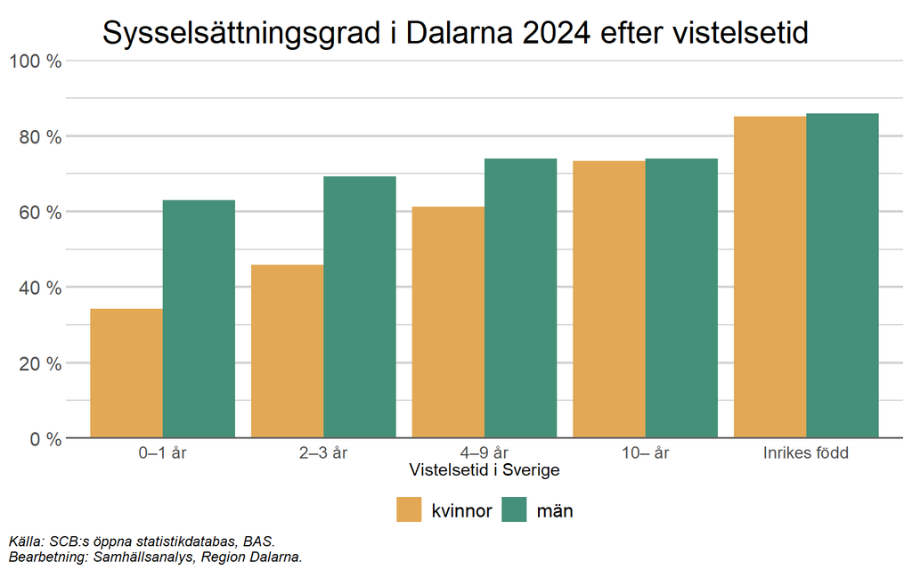

Bland utrikes födda har män en högre sysselsättningsgrad än kvinnor bland dem med vistelsetid kortare än 10 år, men efter 10 år eller längre i Sverige har skillnaden mer eller mindre försvunnit. Bland inrikes födda är sysselsättningsgraden något högre för män än för kvinnor.

Skillnaderna mellan könen minskar som synes med vistelsetiden i Sverige. Mönstret med en stor skillnad i sysselsättningsgrad mellan kön för utrikes födda med en kort vistelsetid går att se även i Dalarna. Skillnaden mellan könen minskar ju längre vistelsetiden i landet blir, och har helt försvunnit för de som bott i Sverige i 10 år eller mer.

Skillnaden mellan utrikes födda kvinnor och utrikes födda män kan även förklaras med att kvinnor som invandrat från ett utomeuropeiskt land i majoriteten av fallen har gjort det som anhörig, antingen till en person med svenskt medborgarskap eller till en person med permanent uppehållstillstånd. Att vara anhörig till arbetskraftsinvandrare är även vanligt förekommande. Givet dessa skäl för invandring är det vanligt att kvinnor invandrar med små barn eller har ett högt barnafödande de första åren i landet. Det har visat sig att kvinnorna sedan tar ett betydligt större omsorgsansvar för barn än barnens fäder, vilket bidrar till att deras inträde på arbetsmarknaden sker betydligt senare än för män i motsvarande situation. Exempelvis är användningen av föräldrapenning mycket ojämställd bland nyligen invandrade föräldrar (se [Expertgruppen för studier i offentlig ekonomi (2021)](https://eso.expertgrupp.se/wp-content/uploads/2020/03/ESO-2021_7_forsorjning-med-fordrojning_webb.pdf)[^11] och [Jämställdhetsmyndigheten (2022)](https://jamstalldhetsmyndigheten.se/media/s5wdbimq/rapport-sta-rkta-mo-jligheter-genom-samverkan.pdf)[^12]).

Hur snabbt en nyligen invandrad person etablerar sig på arbetsmarknaden har förändrats avsevärt över tid, vilket åskådliggörs i diagrammet nedan. Från början av 2000-talet fram till mitten av 2010-talet låg etableringstiden relativt stabil, där ungefär 20 procent av de 20-64 åringar som varit i Sverige i upp till 2 år (0-1 år i figuren nedan) förvärvsarbetade och ungefär 50-60 procent av de 20-64 åringar som varit i Sverige mellan 4 och 10 år (4-9 år i figuren nedan) förvärvsarbetade. Efter den stora flyktinginvandringen i mitten av 2010-talet verkar dock någonting ha hänt och framförallt personer med kort vistelsetid (upp till 2 år) kommer i arbete betydligt snabbare. Mellan 2015 och 2024 ökade andelen förvärvsarbetande av de 20-64 åringar som varit i Sverige i upp till 2 år (0-1 år i figuren nedan) från ungefär 16 procent till cirka 47 procent, en remarkabel förbättring. Under samma tidsperiod har även arbetslösheten för gruppen utrikes födda minskat betydligt, vilket illustrerats i ett tidigare diagram. Värt att notera är att det i diagrammet nedan är andelen förvärvsarbetande i åldersgruppen 20-64 år som redovisas mellan 1997 och 2021, medan det är andelen förvärvsarbetande i åldergruppen 20-65 år som redovisas åren därefter.

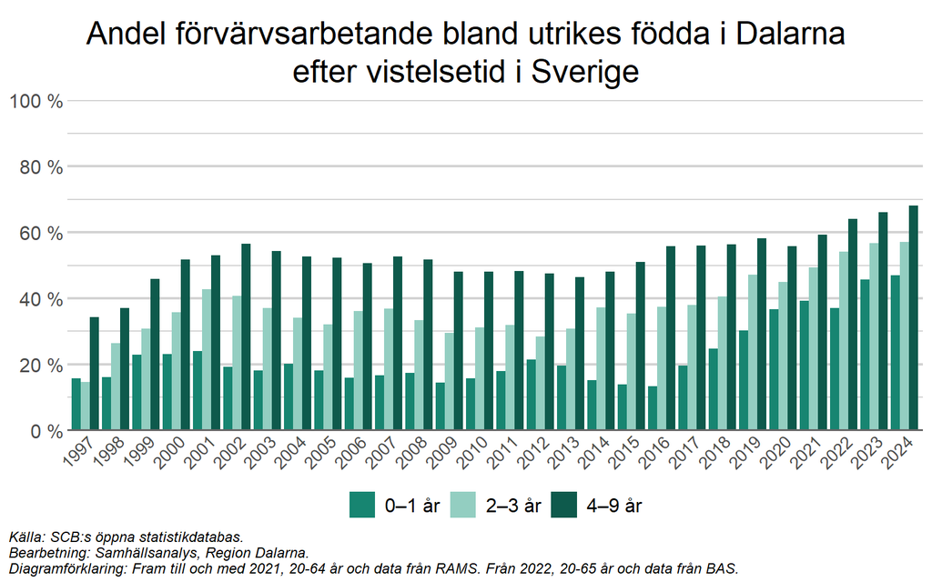

Regeringen har under år 2023 satt fokus på insatser som ska få utrikes födda kvinnor i arbete snabbare. Bland annat har länsstyrelserna ett regionalt uppdrag med detta som mål.

## 3.2 UVAS

Avslutningsvis är det även viktigt att titta på de unga individer som varken arbetar eller studerar (UVAS). För mer information om denna grupp, se exempelvis [MUCF](https://www.mucf.se/publikationer/unga-som-varken-arbetar-eller-studerar-0).

Andelen unga utrikes födda som varken arbetar eller studerar har minskat kraftigt sedan slutet av 1990-talet. Bland 16-19-åringar som varit i Sverige i max 2 år har andelen gått från runt 60 procent till 22 procent idag, och bland 20-25-åringar från runt 70 procent till 28 procent.

Språk och utbildning är avgörande för etablering på arbetsmarknaden. En hög asylinvandring gör att samhället behöver resurssätta för att möta behoven av grundläggande språkutbildning som i sin tur ger möjlighet att tillgodogöra sig utbildning. Det är tydligt att det är en process som kräver tid, men de flesta områden utvecklas också positivt över tid. Under senare år har vistelsetidens påverkan på integrationen förkortats, vilket kan vara ett tecken på att invandringen de senaste åren är av annan karaktär än under åren efter 2015.

# 4 Boende och flyttmönster

Vid sidan om utbildning och arbete, utgör boende och flyttmönster viktiga aspekter för att förstå integrationensprocessen i Dalarna. Boende och flyttmönster kan påverka möjligheterna till arbete, utbildning och sociala kontakter, vilket i sin tur kan påverka integrationen.

## 4.1 Boende

Det finns flera sätt att mäta boende på och alla indikerar boendeskillnader mellan inrikes och utrikes födda. Typ av boende (villa eller lägenhet), boendeyta och bostadsägande säger alla någonting om hur människor bor, något som också speglar den ekonomiska situationen. Det innebär, precis som på de flesta andra områden, att gruppen utrikes födda kommer att ha en stor spridning avseende etablering i samhället. Några i gruppen kommer att ha bott i Sverige i mindre än ett år och andra i flera decennier. Således finns även inom boendeområdet anledning att göra analyser uppdelat på vistelsetid i Sverige.

Ett mått på boendesituationen är andelen trångbodda hushåll. Trångboddhet i lägenheter i flerbostadshus mäts av SCB enligt Norm 2 ([Boverket](https://www.boverket.se/sv/kommunernas-bostadsforsorjning/underlag-bostadsbehov/anstrangd-boendeekonomi/)), vilket innebär att gränsen för trångboddhet går vid högst två personer per rum, exklusive kök och vardagsrum.

De hushåll i Dalarna som är trångbodda utgör en liten andel av det totala antalet lägenhetshushåll, vilket framförallt beror på att få hushåll med inrikes födda är trångbodda (bara ungefär 9 procent år 2024). Bland hushåll med utrikes födda är en klart större andel trångbodda (ungefär 33 procent år 2024). Sedan 2018, kort efter invandringen p g a kriget i Syrien, har antalet hushåll som är trångbodda minskat något för såväl inrikes som utrikes födda.

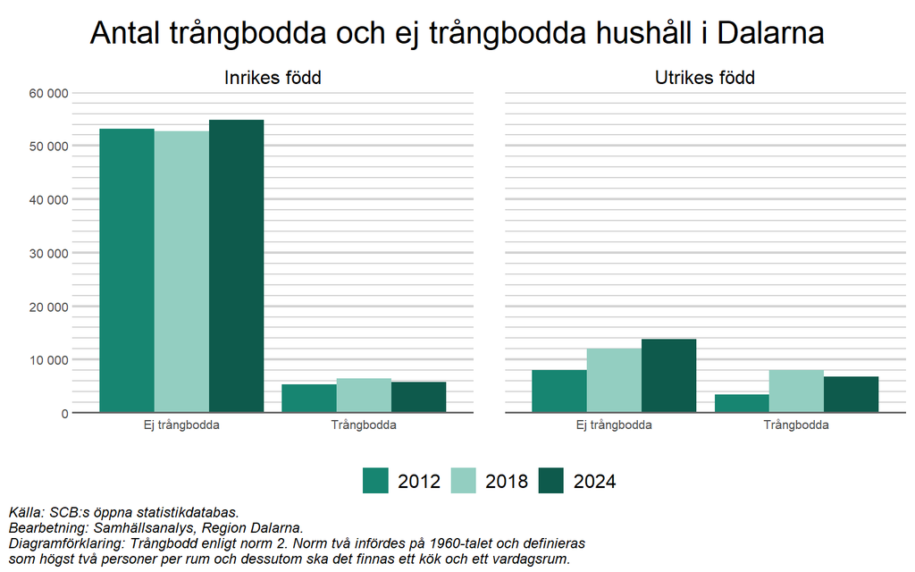

Trångboddhet i småhus kan inte mätas på samma sätt eftersom att uppgifter på antal rum inte samlas in. Det går att mäta med hjälp av bostadsyta per hushållsmedlem även om det måttet blir trubbigare än det för flerbostadshus. Trångboddhet i småhushushåll anses dock inte vara ett utbrett problem, varför endast trångboddhet i flerbostadshus behandlas här.

I Region Dalarnas integrationsrapport från 2019 ([Region Dalarna, 2019](https://www.regiondalarna.se/contentassets/d845727dbc9f49c3b7b09a2c60456497/integrationsanalys.pdf)) konstaterades att många utrikes födda är trångbodda en lång tid efter att de har invandrat. Det finns stora skillnader på bostadsmarknaden mellan de som är inrikes och utrikes födda, samt skillnaderna kan bestå under en väldigt lång tid efter att en person har invandrat till Sverige. Det är också viktigt att känna till att trångboddhet kan vara ett lokalt fenomen. Det är fullt möjligt att många kan vara trångbodda i ett bostadsområde samtidigt som få hushåll är trångbodda i grannområdet.

## 4.2 Flyttmönster

I den här rapporten delas flyttar upp i två typer, inrikes och utrikes. Inrikes flyttar är de som sker mellan olika län i Sverige, medan utrikes flyttar är de som sker mellan Sverige och andra länder och normalt benämns in- respektive utvandring. I texten nedan benämns nettot mellan inrikes in- och utflyttar inrikes flyttnetto alternativt inrikes flyttningsöverskott, medan nettot mellan utrikes in- och utflyttar benämns invandringsöverskott eller utrikes flyttnetto.

Sedan slutet av 1990-talet har Dalarna haft ett negativt inrikes flyttnetto under en överväldigande majoritet av åren

Tydligt är att många av de som invandrade till länet under åren runt 2015-2016 har flyttat därifrån sedan dess. Totalt har 6 828 utrikes födda flyttat från Dalarna till andra län sedan 2017 (netto).

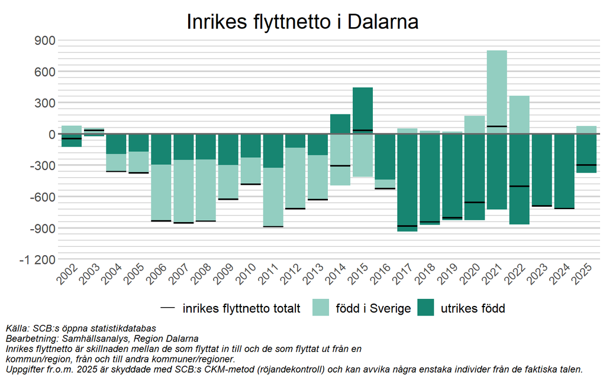

Om invandringsöverskottet minskar och det negativa inrikes flyttnettot består kommer befolkningen i Dalarna att minska över tid. De senaste decenniernas ökning av befolkningen är i huvudsak en effekt av den invandring som varit.

SCB har under 2022 analyserat flyttningar inom kommun, inom län och mellan län under perioden 2002-2021 [(SCB, 2022)](https://www.scb.se/contentassets/1a0f506a930d4df992f9689cecb01c3a/be0701_2022a01_br_be51br2210.pdf)[^13]. Den generella bilden är att antalet flyttningar per år har ökat under perioden, särskilt sedan mitten av 2010-talet. Flyttbenägenheten för utrikes födda har ökat och mellan 2017 och 2021 flyttar utrikes födda dubbelt så ofta som inrikes födda. Det är främst gruppen som bott i Sverige upp till 4 år som flyttar ofta. Utrikes födda med längre vistelsetider uppvisar samma flyttmönster som inrikes födda. Detta mönster noterades även i Region Dalarnas integrationsrapport från 2019. Det konstaterades att denna trend även gällde före år 2014, och att det finns anledning att tro att utflyttningen av nyanlända med kort vistelsetid även i framtiden kommer att vara större än inflyttningen. Trenden är problematisk för Dalarnas del, då redan befintlig och framtida potentiell arbetskraft i och med detta försvinner från länet.

# 5 Ekonomi och demokrati

Utöver områden som språk, utbildning, boende och arbete följer ett antal ytterligare områden som är viktiga för integrationen i samhället. Att ha ekonomiska förutsättningar att utvecklas och demokratiskt engagemang är båda komponenter som behöver analyseras ur ett integrationsperspektiv.

## 5.1 Ekonomi

Utrikes födda personer i Dalarna har generellt sett lägre inkomster än personer födda i Sverige. Detta gäller framför allt de första åren efter flytten till Sverige. Skillnaderna är väsentligt mindre för personer som bott i Sverige en längre tid. Inkomsterna skiljer sig även mellan personer som är födda i olika länder. Oavsett bakgrund har män en högre medianinkomst än kvinnor, något som framförallt gäller under de första åren efter flytten till Sverige.

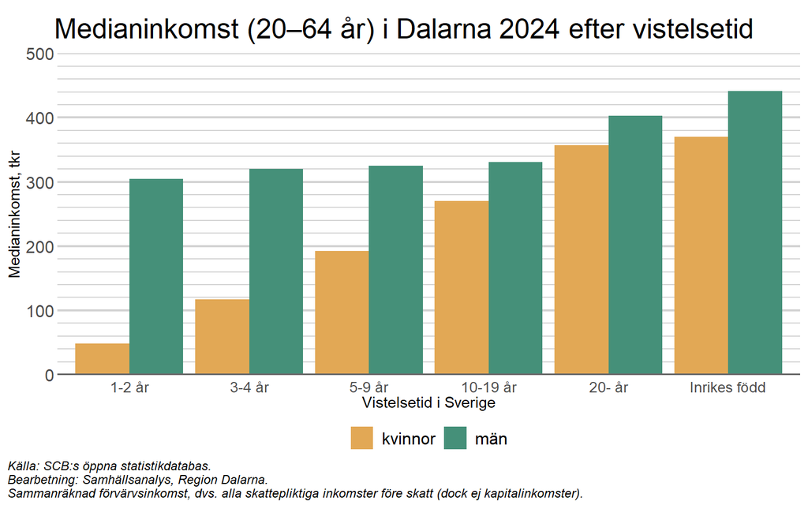

Ett annat sätt att mäta ekonomisk utsatthet är att använda måttet *varaktigt låg ekonomisk standard* som Folkhälsomyndigheten använder för att följa upp folkhälsopolitiken. Med varaktigt låg ekonomisk standard avses de personer som lever i ett hushåll som har en disponibel inkomst per konsumtionsenhet under ett år som är mindre än 60 procent av medianvärdet för samtliga personer samt under minst två av de tre föregående åren (totalt tre av fyra år).

Av de utrikes födda i Sverige hade ungefär 31 procent en varaktigt låg ekonomisk standard år 2024, medan andelen bland de personer som är födda i Sverige var 10 procent. För utrikes födda minskade dock andelen i hushåll med låg ekonomisk standard med 8 procentenheter mellan 2017 och 2024, medan andelen ökade något för inrikes födda.

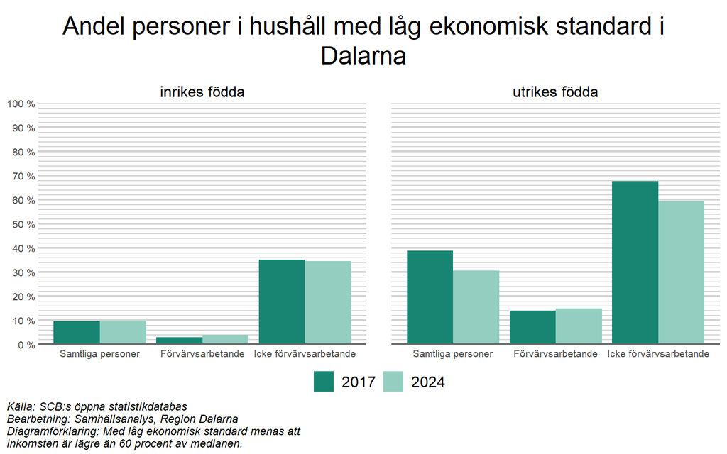

Vid analyser av sysselsättning så är det av stor vikt att också analysera gruppen som inte förvärvsarbetar. Det är ur samhällets perspektiv stor skillnad på om man har sin försörjning från ekonomiskt stöd eller studiemedel. Det senare är en form av investering som vanligtvis leder till högre inkomster för individen framöver, medan det förra är en utväg för individer som inte har kunnat lösa sin försörjning på annat sätt. Just ekonomiskt stöd är den kategori där det finns störst skillnader mellan inrikes och utrikes födda, där ungefär 5 procent av de utrikes födda har sin största inkomstkälla från ekonomiskt stöd mot drygt 1 procent av de inrikes födda. Med ekonomiskt stöd åsyftas ekonomiskt bistånd för sökande och eventuell medsökande, bostadsbidrag för sökande och eventuell medsökande samt äldreförsörjningsstöd.

Även andelen som saknar ersättning är större i gruppen med utrikes födda, knappt 16 procent i augusti 2026, mot 5 procent i gruppen inrikes födda. Behovet av stöd och avsaknaden av ersättningar är två delar som visar på en bristande ekonomisk integration.

Om antalet individer som får ekonomiskt stöd studeras över tid, blir det tydligt att antalet som får stöd minskar, men att minskningen i första hand är koncentrerad till utrikes födda. I januari 2020 var det ungefär 840 fler utrikes födda personer som var i behov av ekonomiskt stöd i Dalarna, jämfört med inrikes födda. I augusti 2026 var det istället fler inrikes än utrikes födda som fick stöd.

Ett annat generellt mönster är att det bland inrikes födda är vanligare att män har ekonomiskt stöd som huvudsaklig inkomst, medan det bland utrikes födda är vanligare att kvinnor har det.

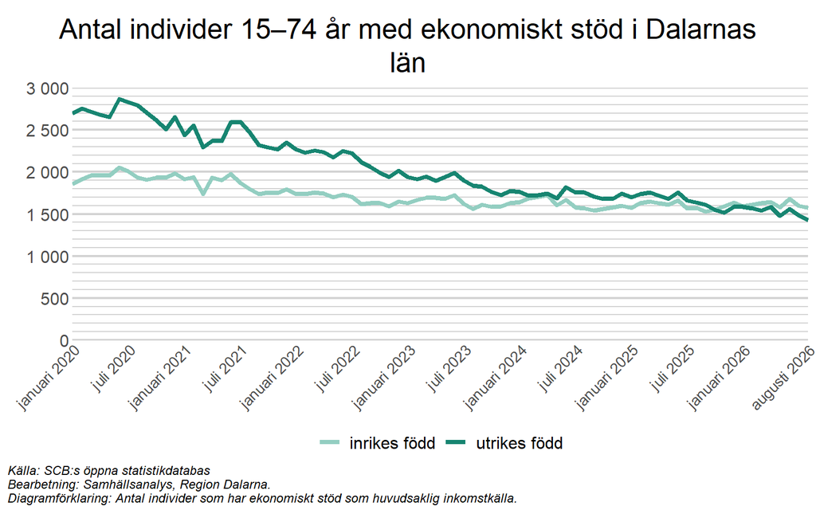

Sammanfattningsvis är det fortsatt stora skillnader mellan inrikes och utrikes födda när det gäller andelar i behov av ekonomiskt stöd respektive saknar ersättningar. De senaste dryga 6 åren har dock antalet personer med ekonomiskt stöd som huvudsaklig inkomstkälla minskat tydligt, framförallt för utrikes födda.

## 5.2 Demokrati

Bland inrikes födda är valdeltagandet i Dalarna, i val till riksdagen, relativt högt (närmare 90 procent) och har inte förändrats nämnvärt mellan valen 2018 och 2022. Utrikes födda har generellt ett lägre valdeltagande och i den gruppen har även valdeltagandet minskat på senare år. Valdeltagandet bland utrikes födda varierar dessutom baserat på hur länge personerna har bott i Sverige. För de som varit i Sverige mindre än 10 år var valdeltagandet i Dalarna, i val till riksdagen år 2022, 66 procent, att jämföra med 73 procent för de som varit i Sverige längre än 10 år.

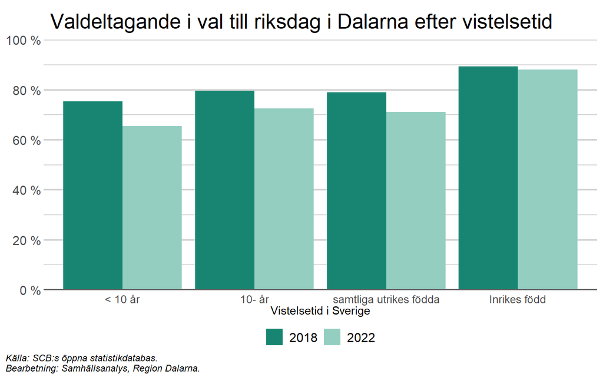

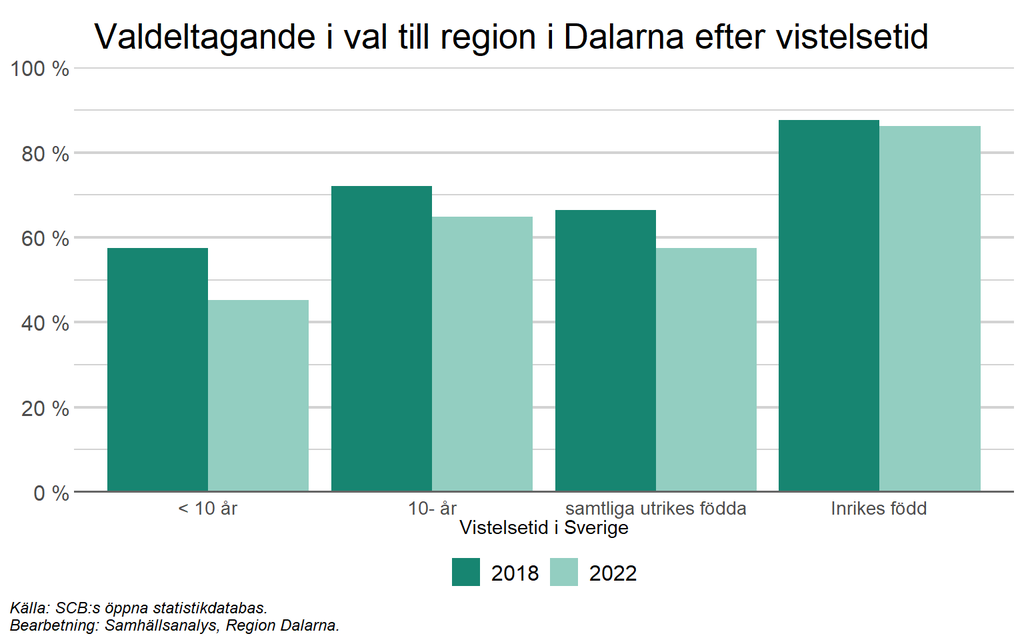

# 6 Avslutning

I denna rapport har integrationen av utrikes födda analyserats utifrån demografi, språk, utbildning, arbetsmarknad, boende, flyttmönster, ekonomi och demokrati. Inom flera områden har det skett en positiv utveckling för utrikes födda och i vissa fall en väldigt positiv utveckling.

Dalarnas inrikes födda befolkning har under de senaste decennierna minskat i antal och fått en förändrad åldersstruktur. Färre i arbetsför ålder ska försörja fler, framförallt äldre, som inte arbetar.

Befolkningstillskottet från utrikes födda som invandrat under det senaste decenniet har bidragit till att begränsa denna negativa demografiska utveckling, dels i antal invånare, dels i en ökad andel i arbetsför ålder som bidragit till en föryngring av länets befolkning.

De generella trenderna över tid för utrikes födda som kan observeras är att

- *Andelen behöriga till gymnasiet och högskolan ökar*
- *Utbildningsnivån ökar*
- *Sysselsättningsgraden ökar*
- *Arbetslösheten minskar markant*
- *Medelinkomsten ökar*
- *Trångboddheten minskar*
- *Andel personer i hushåll med låg ekonomisk standard minskar*
- *Behovet av ekonomiskt stöd minskar*
- *Andelen unga vuxna som inte studerar eller arbetar minskar*
- *Vistelsetiden för godkänt i SFI ökar*

Sammantaget är ovanstående trender utan tvekan väldigt positivt för Dalarna.

Det är tydligt att vistelsetid och utbildningsnivå har en stor betydelse för utfallet på integrationsområdet. Inom de flesta områden som studerats i rapporten syns en väldigt tydlig positiv utveckling av utfallet när antingen vistelsetiden ökar och/eller utbildningsnivån höjs.

Det konstaterades inledningsvis att integration är en process där grupper med olika bakgrund ska bli en del av ett socialt, ekonomiskt och kulturellt sammanhang. Det är därför inte förvånande att vistelsetiden har en tydlig roll i att öka integrationen och minska skillnaderna mellan inrikes och utrikes födda. Beroende på individens förutsättningar kommer tiden till att integreras i samhället att variera.

När det gäller utbildningsnivån finns det en tydlig skiljelinje mellan individer med endast förgymnasial utbildning och de som har gymnasial eller högre utbildningsnivå. De med endast förgymnasial utbildning har svårare att etablera sig på arbetsmarknaden och behöver längre tid för att bland annat nå godkänt i SFI. Utmaningen för de med endast förgymnasial utbildning gäller dock oavsett om individen är inrikes eller utrikes född, men de utrikes födda har en språklig utmaning att möta. Att lära sig svenska skapar möjligheter för att i förlängningen utbilda sig och etablera sig på arbetsmarknaden.

Att uppnå godkänt i SFI har det senaste decenniet tagit allt längre tid i genomsnitt, oavsett utbildningsnivå. Sannolikt är det en kombination av det stora tryck som flyktinginvandringen 2015 och framåt medförde, i kombination med coronapandemins påverkan på utbildningsväsendet. Att förbättra genomströmningen i SFI är en mycket viktig del under kommande år för att rusta utrikes födda inför fortsatt utbildning och etablering på arbetsmarknaden.

Även om det skett en positiv utveckling i många delar finns det generella skillnader mellan inrikes och utrikes födda som kan observeras, även när vistelsetiden i Sverige och utbildningsnivån tas i beaktande. Utrikes födda har exempelvis lägre medianinkomster, en högre andel är trångbodda, lägre valdeltagande, en högre andel arbetslösa och även långtidsarbetslösa.

De skillnader som observeras förtar inte den övergripande positiva utvecklingen inom de områden som analyserats, men de visar samtidigt att det finns mer att göra när det kommer till att utnyttja den resurs som utrikes födda är. Vikten av att fortsätta integrationsarbetet är särskilt viktigt för att kompetensförsörja arbetsmarknaden nu och i framtiden.

De senaste åren har invandringen till länet minskat och antalet utrikes födda i Dalarna har stabiliserats. Samtidigt har Dalarna ett negativt inrikes flyttnetto och låga födelsetal, en kombination som leder till en allt mer åldrad befolkning och utmanar arbetskrafts- och kompetensförsörjningen för näringsliv och offentlig förvaltning framgent. Den demografiska prognosen för det kommande decenniet indikerar en minskad befolkning.

Att säkerställa goda kunskaper i svenska och att lyfta utbildningsnivån för utrikes födda, främst de med endast förgymnasial utbildning, är avgörande för att se en ökad etablering på arbetsmarknaden och en fortsatt positiv utveckling av integrationen av utrikes födda i Dalarna.

# 7 Referenser

[^1]: Region Dalarna, 2019. Nulägesbeskrivning av integrationen i Dalarna, ett regionalt perspektiv. Regionala utvecklingsförvaltningens rapportserie #1.
[^2]: Regeringen. Pressbriefing om migrationen till Sverige under 2024. 2025-01-10.
[^3]: Regeringen, 2015. Långtidsutredningen 2015, Statens Offentliga Utredningar 2015:104.
[^4]: Regeringen, 2019. Långtidsutredningen 2019, Statens Offentliga Utredningar 2019:65.
[^5]: SCB, Statistikdatabasen, Aktuella framskrivningar, Folkmängd efter region, inrikes/utrikes född, ålder och kön. År 2024 - 2070.
[^6]: Westin Lundqvist, W., Assmo, P. och Sunnemark, F., 2019. Låga skolresultat i socialt utsatta områden, Högskolan i Väst.
[^7]: Mörtlund, T., 2020. Arbetet med nyanlända elever i grundskolan, IFAU Rapport 2020:2.
[^8]: IFAU. Utrikes föddas etablering på arbetsmarknaden (2022-11-19).
[^9]: Länsstyrelsen Stockholm, 2018. Antisvart rasism och diskriminering på arbetsmarknaden, Rapport 2018.21.
[^10]: Bursell, M. och Bygren, M., 2023. Etnisk yrkessegregering på arbetsmarknaden – har diskriminering någon betydelse?, Rapport 2023:10, IFAU.
[^11]: Expertgruppen för studier i offentlig ekonomi, 2021. Försörjning med fördröjning – en ESO-rapport om utrikes födda kvinnors etablering på arbetsmarknaden. ESO Rapport 2021:7.
[^12]: Jämställdhetsmyndigheten, 2022. Stärkta möjligheter genom samverkan. Rapport 2022:13.
[^13]: SCB, 2022. Flyttningar inom kommun, inom län och mellan län 2002-2021. Demografiska rapporter 2022:10